# McDonald-Kreitman Test — Standard, Imputed, and Branch-Specific

2026-07-07

```r
library(tidyverse)
library(kableExtra)
library(patchwork)
library(UpSetR)
library(DT)
```

This notebook runs **four McDonald-Kreitman tests** on the merged table produced by `merge_mkt_results.py`, adds ortholog annotations from `orthogroup_table.py`, identifies positive selection candidates, and compares results across focal species.

| Test | Pn used | Dn / Ds source |
| --- | --- | --- |
| Standard MKT | raw Pn | fixN / fixS from dNdSpiNpiS |
| Standard impMKT | PnNeutral (SDM-corrected) | fixN / fixS from dNdSpiNpiS |
| Branch-specific MKT | raw Pn | round(dN × N_codeml) / round(dS × S_codeml) |
| Branch-specific impMKT | PnNeutral (SDM-corrected) | round(dN × N_codeml) / round(dS × S_codeml) |

Branch-specific Dn and Ds convert codeml rate estimates back to divergence counts:
$$D_N^{branch} =
\text{round}(dN \times N_{codeml}), \quad D_S^{branch} = \text{round}(dS
\times S_{codeml})$$

## 1 Load data

### 1.1 Merged results table

```r
df <- read_tsv(
  params$merged_table,
  col_types = cols(.default   = col_double(),
                   gene_id    = col_character(),
                   ortholog   = col_character(),
                   species    = col_character(),
                   downsampled = col_character(),
                   nt_engine  = col_character()),
  na = c("NA", "NaN", "")
)

cat(sprintf("Loaded %d genes  |  %d columns\n", nrow(df), ncol(df)))
```

```
## Loaded 3560 genes  |  73 columns
```

```r
cat(sprintf("Species              : %s\n", params$species))
```

```
## Species              : Aegilopsspeltoides
```

```r
cat(sprintf("Genes with dn_counts : %d\n", sum(!is.na(df$dn_counts))))
```

```
## Genes with dn_counts : 3513
```

```r
cat(sprintf("Genes with dN codeml : %d\n", sum(!is.na(df$dN))))
```

```
## Genes with dN codeml : 3544
```

### 1.2 Orthogroup table → ortholog columns

Ortholog gene IDs for every species in the orthogroup are joined by HOG ID (`ortholog` column). Column names are built from the last word of each species name (e.g. `Aegilops_speltoides` → `speltoides_ortholog`).

```r
ortho_raw <- read_tsv(params$orthogroup_table, col_types = cols(.default = col_character()))
# Rename first column to "ortholog" regardless of its actual name
colnames(ortho_raw)[1] <- "ortholog"

ortho_species <- setdiff(colnames(ortho_raw), "ortholog")

# Short name: last word after the final underscore
short_name <- function(sp) sub(".*_", "", sp)

# Auto-detect which orthogroup-table column corresponds to the focal species.
# Strategy: remove underscores and lowercase, match against the 'species' column
# in the merged table (which uses the same cleaned convention).
if (nchar(params$focal_species_in_ortho_table) > 0) {
  focal_sp_col <- params$focal_species_in_ortho_table
} else {
  sp_from_data  <- tolower(unique(na.omit(df$species))[1])
  ortho_clean   <- tolower(gsub("_", "", ortho_species))
  match_idx     <- which(ortho_clean == sp_from_data)
  if (length(match_idx) == 1L) {
    focal_sp_col <- ortho_species[match_idx]
    cat("Auto-detected focal species column:", focal_sp_col, "\n")
  } else {
    stop("Could not auto-detect focal species in orthogroup table.\n",
         "Set params$focal_species_in_ortho_table explicitly.\n",
         "Available columns: ", paste(ortho_species, collapse = ", "))
  }
}

# Build rename map:  old "Aegilops_mutica" → new "mutica_ortholog"
# dplyr convention for rename(all_of(x)): names = new names, values = old names
rename_map <- setNames(
  ortho_species,
  paste0(sapply(ortho_species, short_name), "_ortholog")
)

ortho_renamed <- ortho_raw %>%
  rename(all_of(rename_map))

ortholog_cols <- paste0(sapply(ortho_species, short_name), "_ortholog")
new_name_of_focal <- paste0(short_name(focal_sp_col), "_ortholog")
focal_ortho_col <- new_name_of_focal   # e.g. "speltoides_ortholog"
other_ortho_cols <- setdiff(ortholog_cols, focal_ortho_col)

cat("Orthogroup table: ", nrow(ortho_renamed), "HOGs × ",
    length(ortho_species), "species\n")
```

```
## Orthogroup table:  3550 HOGs ×  3 species
```

```r
cat("Focal species column: ", focal_ortho_col, "\n")
```

```
## Focal species column:  speltoides_ortholog
```

```r
cat("Other species:       ", paste(other_ortho_cols, collapse = ", "), "\n")
```

```
## Other species:        mutica_ortholog, tauschii_ortholog
```

```r
# Join orthogroup info into main data frame
df <- df %>% left_join(ortho_renamed, by = "ortholog")

n_matched <- sum(!is.na(df[[focal_ortho_col]]))
cat(sprintf("\nOrthogroup join: %d / %d genes matched a HOG\n", n_matched, nrow(df)))
```

```
##
## Orthogroup join: 3544 / 3560 genes matched a HOG
```

## 2 Helper functions

```r
# Fisher's exact test on the MK 2×2 table [[Pn, Dn], [Ps, Ds]]
mk_fisher <- function(Pn, Ps, Dn, Ds) {
  mapply(function(pn, ps, dn, ds) {
    if (any(is.na(c(pn, ps, dn, ds)))) return(NA_real_)
    if (any(c(pn, ps, dn, ds) < 0))   return(NA_real_)
    tryCatch(
      fisher.test(matrix(c(round(pn), round(ps), round(dn), round(ds)),
                         nrow = 2))$p.value,
      error = function(e) NA_real_
    )
  }, Pn, Ps, Dn, Ds, SIMPLIFY = TRUE)
}

# DoS = Dn/(Dn+Ds) − Pn/(Pn+Ps)  (Stoletzki & Eyre-Walker 2011)
compute_dos <- function(Pn, Ps, Dn, Ds) {
  ifelse(!is.na(Dn) & !is.na(Ds) & (Dn + Ds) > 0, Dn / (Dn + Ds), NA_real_) -
  ifelse(!is.na(Pn) & !is.na(Ps) & (Pn + Ps) > 0, Pn / (Pn + Ps), NA_real_)
}

# α = 1 − (Ds × Pn) / (Dn × Ps)
compute_alpha <- function(Pn, Ps, Dn, Ds) {
  ifelse(!is.na(Dn) & !is.na(Ps) & Dn > 0 & Ps > 0,
         1 - (Ds * Pn) / (Dn * Ps), NA_real_)
}

# Standard MKT filter: Pn+Ps ≥ 5, all four cells ≥ 1
mk_filter <- function(Pn, Ps, Dn, Ds) {
  !is.na(Pn) & Pn >= 1 & !is.na(Ps) & Ps >= 1 &
  !is.na(Dn) & Dn >= 1 & !is.na(Ds) & Ds >= 1 &
  (Pn + Ps) >= 5
}

# Positive candidate: DoS > 0 AND raw p < 0.05
is_positive <- function(DoS, pval) {
  !is.na(DoS) & DoS > 0 & !is.na(pval) & pval < 0.05
}
```

## 3 Branch-specific divergence counts

```r
df <- df %>%
  mutate(
    Dn_branch_specific = round(dN * N_codeml),
    Ds_branch_specific = round(dS * S_codeml),
    DnDs_branch_specific_counts = ifelse(
      !is.na(Ds_branch_specific) & Ds_branch_specific > 0,
      Dn_branch_specific / Ds_branch_specific, NA_real_
    )
  )

cat(sprintf("Dn_branch_specific  — n: %d  median: %.1f  mean: %.2f\n",
    sum(!is.na(df$Dn_branch_specific)),
    median(df$Dn_branch_specific, na.rm = TRUE),
    mean(df$Dn_branch_specific,   na.rm = TRUE)))
```

```
## Dn_branch_specific  — n: 3544  median: 2.0  mean: 4.00
```

```r
cat(sprintf("Ds_branch_specific  — n: %d  median: %.1f  mean: %.2f\n",
    sum(!is.na(df$Ds_branch_specific)),
    median(df$Ds_branch_specific, na.rm = TRUE),
    mean(df$Ds_branch_specific,   na.rm = TRUE)))
```

```
## Ds_branch_specific  — n: 3544  median: 8.0  mean: 10.59
```

## 4 MKT tests

### 4.1 Standard MKT

Dn/Ds = fixN/fixS (dNdSpiNpiS). Filter: Pn + Ps ≥ 5, all cells ≥ 1.

```r
std <- df %>%
  mutate(
    Pn = num_pol_NS,
    Ps = num_pol_S,
    Dn = dn_counts,
    Ds = ds_counts,
    standard_MKT        = compute_alpha(Pn, Ps, Dn, Ds),
    DoS_MKT_standard    = compute_dos(Pn, Ps, Dn, Ds),
    standard_MKT_pvalue = mk_fisher(Pn, Ps, Dn, Ds)
  )

std_mask <- mk_filter(std$Pn, std$Ps, std$Dn, std$Ds)
std <- std %>% mutate(standard_MKT_p_adj = NA_real_)
if (any(std_mask))
  std$standard_MKT_p_adj[std_mask] <-
    p.adjust(std$standard_MKT_pvalue[std_mask], method = "BH")

std_filtered <- std %>% filter(std_mask)
cat(sprintf("Standard MKT     : %d / %d genes passed filter\n",
            nrow(std_filtered), nrow(df)))
```

```
## Standard MKT     : 2153 / 3560 genes passed filter
```

### 4.2 Standard impMKT

```r
imp <- std %>%
  mutate(
    PnNeutral_safe         = pmax(0, pmin(PnNeutral_estimation, num_pol_NS)),
    standard_impMKT        = compute_alpha(PnNeutral_safe, Ps, Dn, Ds),
    DoS_impMKT_standard    = compute_dos(PnNeutral_safe, Ps, Dn, Ds),
    standard_impMKT_pvalue = mk_fisher(PnNeutral_safe, Ps, Dn, Ds)
  )

imp_mask <- mk_filter(imp$PnNeutral_safe, imp$Ps, imp$Dn, imp$Ds)
imp <- imp %>% mutate(standard_impMKT_p_adj = NA_real_)
if (any(imp_mask))
  imp$standard_impMKT_p_adj[imp_mask] <-
    p.adjust(imp$standard_impMKT_pvalue[imp_mask], method = "BH")

imp_filtered <- imp %>% filter(imp_mask)
cat(sprintf("Standard impMKT  : %d / %d genes passed filter\n",
            nrow(imp_filtered), nrow(df)))
```

```
## Standard impMKT  : 1703 / 3560 genes passed filter
```

### 4.3 Branch-specific MKT

Dn/Ds = round(dN × N_codeml) / round(dS × S_codeml).

```r
bs <- imp %>%
  mutate(
    Dn_bs = Dn_branch_specific,
    Ds_bs = Ds_branch_specific,
    branch_specific_MKT        = compute_alpha(Pn, Ps, Dn_bs, Ds_bs),
    DoS_branch_specific_MKT    = compute_dos(Pn, Ps, Dn_bs, Ds_bs),
    branch_specific_MKT_pvalue = mk_fisher(Pn, Ps, Dn_bs, Ds_bs)
  )

bs_mask <- mk_filter(bs$Pn, bs$Ps, bs$Dn_bs, bs$Ds_bs)
bs <- bs %>% mutate(branch_specific_MKT_p_adj = NA_real_)
if (any(bs_mask))
  bs$branch_specific_MKT_p_adj[bs_mask] <-
    p.adjust(bs$branch_specific_MKT_pvalue[bs_mask], method = "BH")

bs_filtered <- bs %>% filter(bs_mask)
cat(sprintf("Branch-spec MKT  : %d / %d genes passed filter\n",
            nrow(bs_filtered), nrow(df)))
```

```
## Branch-spec MKT  : 2315 / 3560 genes passed filter
```

### 4.4 Branch-specific impMKT

```r
bs_imp <- bs %>%
  mutate(
    branch_specific_impMKT        = compute_alpha(PnNeutral_safe, Ps, Dn_bs, Ds_bs),
    DoS_branch_specific_impMKT    = compute_dos(PnNeutral_safe, Ps, Dn_bs, Ds_bs),
    branch_specific_impMKT_pvalue = mk_fisher(PnNeutral_safe, Ps, Dn_bs, Ds_bs)
  )

bs_imp_mask <- mk_filter(bs_imp$PnNeutral_safe, bs_imp$Ps, bs_imp$Dn_bs, bs_imp$Ds_bs)
bs_imp <- bs_imp %>% mutate(branch_specific_impMKT_p_adj = NA_real_)
if (any(bs_imp_mask))
  bs_imp$branch_specific_impMKT_p_adj[bs_imp_mask] <-
    p.adjust(bs_imp$branch_specific_impMKT_pvalue[bs_imp_mask], method = "BH")

bs_imp_filtered <- bs_imp %>% filter(bs_imp_mask)
cat(sprintf("Branch-spec impMKT: %d / %d genes passed filter\n",
            nrow(bs_imp_filtered), nrow(df)))
```

```
## Branch-spec impMKT: 1856 / 3560 genes passed filter
```

### 4.5 Mark positive candidates

A gene is a **positive candidate** if DoS > 0 AND raw p-value < 0.05 in at least one of the four tests.

```r
# A gene can only be a candidate for a given test if it also passes that
# test's own mk_filter() (Pn/Ps/Dn/Ds >= 1 and Pn+Ps >= 5) — otherwise DoS/p
# are computed from too few counts to be meaningful (see std_mask/imp_mask/
# bs_mask/bs_imp_mask above).
bs_imp <- bs_imp %>%
  mutate(
    pos_standard_MKT           = is_positive(DoS_MKT_standard,          standard_MKT_pvalue)          & std_mask,
    pos_standard_impMKT        = is_positive(DoS_impMKT_standard,        standard_impMKT_pvalue)        & imp_mask,
    pos_branch_specific_MKT    = is_positive(DoS_branch_specific_MKT,    branch_specific_MKT_pvalue)    & bs_mask,
    pos_branch_specific_impMKT = is_positive(DoS_branch_specific_impMKT, branch_specific_impMKT_pvalue) & bs_imp_mask,
    pos_any    = pos_standard_MKT | pos_standard_impMKT |
                 pos_branch_specific_MKT | pos_branch_specific_impMKT,
    pos_any_bs = pos_branch_specific_MKT | pos_branch_specific_impMKT,
    # Comma-separated list of all tests where this gene is a positive candidate
    method = pmap_chr(
      list(pos_standard_MKT, pos_standard_impMKT,
           pos_branch_specific_MKT, pos_branch_specific_impMKT),
      function(a, b, c, d) {
        paste(c(
          "Standard MKT"[isTRUE(a)],
          "Standard impMKT"[isTRUE(b)],
          "Branch-specific MKT"[isTRUE(c)],
          "Branch-specific impMKT"[isTRUE(d)]
        ), collapse = ", ")
      }
    )
  )

cat(sprintf("Positive candidates (any test) : %d genes\n",
            sum(bs_imp$pos_any, na.rm = TRUE)))
```

```
## Positive candidates (any test) : 283 genes
```

```r
cat(sprintf("  of which branch-specific only: %d genes\n",
            sum(bs_imp$pos_any_bs & !bs_imp$pos_standard_MKT &
                !bs_imp$pos_standard_impMKT, na.rm = TRUE)))
```

```
##   of which branch-specific only: 67 genes
```

## 5 Output results table

```r
results <- bs_imp %>%
  mutate(PnNeutral = round(PnNeutral_safe)) %>%
  select(
    gene_id, ortholog, all_of(ortholog_cols),
    number_sites, num_codons_eff,
    Pi_per_site, pi_S, pi_NS, thetaW_per_site, Tajimas_D,
    num_sites_S_egglib, num_sites_NS_egglib,
    polymorphism_count, num_pol_S, num_pol_NS, sample_size,
    PnMinus, PnGreater, PsMinus, PsGreater,
    ratioPs, PnNeutral_estimation,
    PnNeutral, deleterious,
    dn_counts, ds_counts,
    dN, dS, N_codeml, S_codeml, omega,
    lnL_branch_model, lnL_m0_model, omega_m0, omega_diff,
    Dn_branch_specific, Ds_branch_specific, DnDs_branch_specific_counts,
    standard_MKT,        standard_impMKT,
    branch_specific_MKT, branch_specific_impMKT,
    DoS_MKT_standard,    standard_MKT_pvalue,    standard_MKT_p_adj,
    DoS_impMKT_standard, standard_impMKT_pvalue, standard_impMKT_p_adj,
    DoS_branch_specific_MKT,    branch_specific_MKT_pvalue,    branch_specific_MKT_p_adj,
    DoS_branch_specific_impMKT, branch_specific_impMKT_pvalue, branch_specific_impMKT_p_adj,
    pos_standard_MKT, pos_standard_impMKT,
    pos_branch_specific_MKT, pos_branch_specific_impMKT
  )

write_tsv(results, params$output_table, na = "NA")
cat(sprintf("Written: %s  (%d genes, %d columns)\n",
            params$output_table, nrow(results), ncol(results)))
```

```
## Written: C:\Users\barrientos\Documents\data\MKT_2024\article\Scripts\test\speltoides\06_results\branch_specific_MKT_results.tsv  (3560 genes, 60 columns)
```

## 6 Summary statistics

```r
bind_rows(
  std_filtered %>% summarise(
    Test             = "Standard MKT",
    n_genes_tested   = n(),
    n_DoS_positive   = sum(DoS_MKT_standard > 0, na.rm = TRUE),
    n_sig_raw_p05    = sum(standard_MKT_pvalue < 0.05, na.rm = TRUE),
    n_pos_selected   = sum(DoS_MKT_standard > 0 & standard_MKT_pvalue < 0.05, na.rm = TRUE),
    pct_pos_selected = round(100 * n_pos_selected / n_genes_tested, 1),
    median_DoS       = round(median(DoS_MKT_standard, na.rm = TRUE), 4),
    median_alpha     = round(median(standard_MKT, na.rm = TRUE), 4)
  ),
  imp_filtered %>% summarise(
    Test             = "Standard impMKT",
    n_genes_tested   = n(),
    n_DoS_positive   = sum(DoS_impMKT_standard > 0, na.rm = TRUE),
    n_sig_raw_p05    = sum(standard_impMKT_pvalue < 0.05, na.rm = TRUE),
    n_pos_selected   = sum(DoS_impMKT_standard > 0 & standard_impMKT_pvalue < 0.05, na.rm = TRUE),
    pct_pos_selected = round(100 * n_pos_selected / n_genes_tested, 1),
    median_DoS       = round(median(DoS_impMKT_standard, na.rm = TRUE), 4),
    median_alpha     = round(median(standard_impMKT, na.rm = TRUE), 4)
  ),
  bs_filtered %>% summarise(
    Test             = "Branch-specific MKT",
    n_genes_tested   = n(),
    n_DoS_positive   = sum(DoS_branch_specific_MKT > 0, na.rm = TRUE),
    n_sig_raw_p05    = sum(branch_specific_MKT_pvalue < 0.05, na.rm = TRUE),
    n_pos_selected   = sum(DoS_branch_specific_MKT > 0 & branch_specific_MKT_pvalue < 0.05, na.rm = TRUE),
    pct_pos_selected = round(100 * n_pos_selected / n_genes_tested, 1),
    median_DoS       = round(median(DoS_branch_specific_MKT, na.rm = TRUE), 4),
    median_alpha     = round(median(branch_specific_MKT, na.rm = TRUE), 4)
  ),
  bs_imp_filtered %>% summarise(
    Test             = "Branch-specific impMKT",
    n_genes_tested   = n(),
    n_DoS_positive   = sum(DoS_branch_specific_impMKT > 0, na.rm = TRUE),
    n_sig_raw_p05    = sum(branch_specific_impMKT_pvalue < 0.05, na.rm = TRUE),
    n_pos_selected   = sum(DoS_branch_specific_impMKT > 0 & branch_specific_impMKT_pvalue < 0.05, na.rm = TRUE),
    pct_pos_selected = round(100 * n_pos_selected / n_genes_tested, 1),
    median_DoS       = round(median(DoS_branch_specific_impMKT, na.rm = TRUE), 4),
    median_alpha     = round(median(branch_specific_impMKT, na.rm = TRUE), 4)
  )
) %>%
  kbl(caption = sprintf("MKT summary — %s", params$species)) %>%
  kable_styling(bootstrap_options = c("striped", "hover", "condensed"))
```

MKT summary — Aegilopsspeltoides

| Test | n_genes_tested | n_DoS_positive | n_sig_raw_p05 | n_pos_selected | pct_pos_selected | median_DoS | median_alpha |
| --- | --- | --- | --- | --- | --- | --- | --- |
| Standard MKT | 2153 | 1325 | 156 | 134 | 6.2 | 0.0513 | 0.2500 |
| Standard impMKT | 1703 | 1219 | 191 | 186 | 10.9 | 0.0873 | 0.4146 |
| Branch-specific MKT | 2315 | 1263 | 94 | 73 | 3.2 | 0.0179 | 0.1020 |
| Branch-specific impMKT | 1856 | 1228 | 120 | 113 | 6.1 | 0.0550 | 0.3000 |

## 7 Positive selection candidates

### 7.1 All positive candidates (any test)

Genes with DoS > 0 and raw p-value < 0.05 in **at least one** of the four tests.

```r
# Base columns for the candidate tables
base_cols <- c("gene_id", "ortholog", "method", ortholog_cols)

candidates_all <- bs_imp %>%
  filter(pos_any) %>%
  mutate(focal_species = params$species) %>%
  select(focal_species, all_of(base_cols),
         DoS_MKT_standard, standard_MKT_pvalue, standard_MKT_p_adj,
         DoS_impMKT_standard, standard_impMKT_pvalue, standard_impMKT_p_adj,
         DoS_branch_specific_MKT, branch_specific_MKT_pvalue, branch_specific_MKT_p_adj,
         DoS_branch_specific_impMKT, branch_specific_impMKT_pvalue, branch_specific_impMKT_p_adj,
         pos_standard_MKT, pos_standard_impMKT,
         pos_branch_specific_MKT, pos_branch_specific_impMKT) %>%
  arrange(gene_id)

cat(sprintf("All positive candidates: %d genes\n", nrow(candidates_all)))
```

```
## All positive candidates: 283 genes
```

```r
# ── Cross-species annotation (only when other_results are provided) ─────────
# For each other focal species, load its result file, identify positive genes,
# and add in_<species> and <species>_method columns to candidates_all.
# The link is the HOG identifier (ortholog column, shared across species).

has_other <- length(params$other_results) > 0

if (has_other) {
  for (sp_full in names(params$other_results)) {
    sp_file  <- params$other_results[[sp_full]]
    sp_short <- tolower(sub(".*_", "", sp_full))   # e.g. "mutica"
    in_col   <- paste0("in_", sp_short)
    meth_col <- paste0(sp_short, "_method")

    if (!file.exists(sp_file)) {
      warning("Other species file not found, skipping: ", sp_file)
      next
    }

    sp_data <- read_tsv(sp_file,
                        col_types = cols(.default  = col_double(),
                                         gene_id   = col_character(),
                                         ortholog  = col_character()),
                        na = c("NA", "NaN", "")) %>%
      filter(!is.na(ortholog)) %>%
      mutate(
        # Re-derive each test's mk_filter() mask from the raw counts carried
        # in that species' own output table (the live std_mask/imp_mask/...
        # vectors from this session don't apply to a different species' file).
        pos_std    = is_positive(DoS_MKT_standard,         standard_MKT_pvalue) &
                     mk_filter(num_pol_NS, num_pol_S, dn_counts, ds_counts),
        pos_imp    = is_positive(DoS_impMKT_standard,       standard_impMKT_pvalue) &
                     mk_filter(PnNeutral, num_pol_S, dn_counts, ds_counts),
        pos_bs     = is_positive(DoS_branch_specific_MKT,   branch_specific_MKT_pvalue) &
                     mk_filter(num_pol_NS, num_pol_S, Dn_branch_specific, Ds_branch_specific),
        pos_bs_imp = is_positive(DoS_branch_specific_impMKT, branch_specific_impMKT_pvalue) &
                     mk_filter(PnNeutral, num_pol_S, Dn_branch_specific, Ds_branch_specific)
      ) %>%
      filter(pos_std | pos_imp | pos_bs | pos_bs_imp) %>%
      mutate(
        !!meth_col := pmap_chr(
          list(pos_std, pos_imp, pos_bs, pos_bs_imp),
          function(a, b, c, d) {
            paste(c(
              "Standard MKT"[isTRUE(a)],
              "Standard impMKT"[isTRUE(b)],
              "Branch-specific MKT"[isTRUE(c)],
              "Branch-specific impMKT"[isTRUE(d)]
            ), collapse = ", ")
          }
        )
      ) %>%
      select(ortholog, !!meth_col)

    candidates_all <- candidates_all %>%
      left_join(sp_data, by = "ortholog") %>%
      mutate(!!in_col := !is.na(.data[[meth_col]]))

    cat(sprintf("  Cross-species: %d candidates have a positive ortholog in %s\n",
                sum(candidates_all[[in_col]], na.rm = TRUE), sp_full))
  }
}
```

```r
write_tsv(candidates_all, params$candidates_table_all, na = "NA")
cat(sprintf("Written: %s\n", params$candidates_table_all))
```

```
## Written: C:\Users\barrientos\Documents\data\MKT_2024\article\Scripts\test\speltoides\06_results\candidates_all.tsv
```

```r
# Interactive table: display key columns
display_cols <- c("gene_id", "ortholog", "method", ortholog_cols)
if (has_other) {
  extra <- names(params$other_results) %>%
    lapply(function(sp) {
      sh <- tolower(sub(".*_", "", sp))
      c(paste0("in_", sh), paste0(sh, "_method"))
    }) %>% unlist()
  display_cols <- c(display_cols, extra)
}

candidates_all %>%
  select(any_of(display_cols)) %>%
  datatable(
    caption = sprintf("All positive candidates — %s (%d genes)",
                      params$species, nrow(candidates_all)),
    filter  = "top",
    options = list(pageLength = 15, scrollX = TRUE)
  )
```

|  | gene_id | ortholog | method | mutica_ortholog | speltoides_ortholog | tauschii_ortholog |
| --- | --- | --- | --- | --- | --- | --- |
| 1 | EVM0000336_1_HOG0004902 | HOG0004902 | Standard MKT, Standard impMKT, Branch-specific impMKT | Ammut_EIv1.0_0499290.1 | EVM0000336.1 | transcript_AET4Gv20640600.2 |
| 2 | EVM0000879_1_HOG0014904 | HOG0014904 | Standard impMKT | Ammut_EIv1.0_0029920.1 | EVM0000879.1 | transcript_AET1Gv20215500.2 |
| 3 | EVM0001055_1_HOG0014129 | HOG0014129 | Standard impMKT, Branch-specific MKT, Branch-specific impMKT | Ammut_EIv1.0_0632020.1 | EVM0001055.1 | transcript_AET5Gv20916800.5 |
| 4 | EVM0001159_2_HOG0022581 | HOG0022581 | Standard MKT, Branch-specific MKT | Ammut_EIv1.0_0942090.1 | EVM0001159.2 | transcript_AET7Gv21300100.15 |
| 5 | EVM0001665_1_HOG0005746 | HOG0005746 | Standard impMKT, Branch-specific impMKT | Ammut_EIv1.0_0850690.1 | EVM0001665.1 | transcript_AET7Gv20529200.3 |
| 6 | EVM0001690_1_HOG0016999 | HOG0016999 | Standard MKT, Standard impMKT | Ammut_EIv1.0_0451590.1 | EVM0001690.1 | transcript_AET4Gv20234700.2 |
| 7 | EVM0002259_1_HOG0026020 | HOG0026020 | Branch-specific impMKT | Ammut_EIv1.0_0375890.1 | EVM0002259.1 | transcript_AET3Gv20877800.4 |
| 8 | EVM0002311_1_HOG0024439 | HOG0024439 | Standard MKT, Standard impMKT, Branch-specific MKT, Branch-specific impMKT | Ammut_EIv1.0_0289250.1 | EVM0002311.1 | transcript_AET3Gv20131900.32 |
| 9 | EVM0002463_1_HOG0016916 | HOG0016916 | Standard MKT, Standard impMKT, Branch-specific impMKT | Ammut_EIv1.0_0448200.1 | EVM0002463.1 | transcript_AET4Gv20194500.3 |
| 10 | EVM0002646_1_HOG0024283 | HOG0024283 | Standard impMKT | Ammut_EIv1.0_0790660.1 | EVM0002646.1 | transcript_AET6Gv21017200.3 |

[output cut: 273 more lines]

### 7.2 Branch-specific candidates

Genes detected by **at least one branch-specific test** (Branch-specific MKT or Branch-specific impMKT), regardless of standard test results.

```r
candidates_bs <- bs_imp %>%
  filter(pos_any_bs) %>%
  mutate(focal_species = params$species) %>%
  select(focal_species, all_of(base_cols),
         DoS_branch_specific_MKT, branch_specific_MKT_pvalue, branch_specific_MKT_p_adj,
         DoS_branch_specific_impMKT, branch_specific_impMKT_pvalue, branch_specific_impMKT_p_adj,
         pos_branch_specific_MKT, pos_branch_specific_impMKT) %>%
  arrange(gene_id)

cat(sprintf("Branch-specific positive candidates: %d genes\n", nrow(candidates_bs)))
```

```
## Branch-specific positive candidates: 131 genes
```

```r
cat(sprintf("  Also positive in ≥1 standard test: %d\n",
    sum(candidates_bs$gene_id %in%
        filter(bs_imp, pos_standard_MKT | pos_standard_impMKT)$gene_id)))
```

```
##   Also positive in ≥1 standard test: 64
```

```r
cat(sprintf("  Unique to branch-specific tests  : %d\n",
    sum(!candidates_bs$gene_id %in%
        filter(bs_imp, pos_standard_MKT | pos_standard_impMKT)$gene_id)))
```

```
##   Unique to branch-specific tests  : 67
```

```r
# Add cross-species columns if already computed in candidates_all
if (has_other) {
  cross_cols <- names(params$other_results) %>%
    lapply(function(sp) {
      sh <- tolower(sub(".*_", "", sp))
      c(paste0("in_", sh), paste0(sh, "_method"))
    }) %>% unlist()
  cross_avail <- intersect(cross_cols, colnames(candidates_all))
  if (length(cross_avail) > 0) {
    candidates_bs <- candidates_bs %>%
      left_join(
        candidates_all %>% select(gene_id, all_of(cross_avail)),
        by = "gene_id"
      )
  }
}

write_tsv(candidates_bs, params$candidates_table_bs, na = "NA")
cat(sprintf("Written: %s\n", params$candidates_table_bs))
```

```
## Written: C:\Users\barrientos\Documents\data\MKT_2024\article\Scripts\test\speltoides\06_results\candidates_branch_specific.tsv
```

```r
candidates_bs %>%
  select(any_of(display_cols)) %>%
  datatable(
    caption = sprintf("Branch-specific candidates — %s (%d genes)",
                      params$species, nrow(candidates_bs)),
    filter  = "top",
    options = list(pageLength = 15, scrollX = TRUE)
  )
```

|  | gene_id | ortholog | method | mutica_ortholog | speltoides_ortholog | tauschii_ortholog |
| --- | --- | --- | --- | --- | --- | --- |
| 1 | EVM0000336_1_HOG0004902 | HOG0004902 | Standard MKT, Standard impMKT, Branch-specific impMKT | Ammut_EIv1.0_0499290.1 | EVM0000336.1 | transcript_AET4Gv20640600.2 |
| 2 | EVM0001055_1_HOG0014129 | HOG0014129 | Standard impMKT, Branch-specific MKT, Branch-specific impMKT | Ammut_EIv1.0_0632020.1 | EVM0001055.1 | transcript_AET5Gv20916800.5 |
| 3 | EVM0001159_2_HOG0022581 | HOG0022581 | Standard MKT, Branch-specific MKT | Ammut_EIv1.0_0942090.1 | EVM0001159.2 | transcript_AET7Gv21300100.15 |
| 4 | EVM0001665_1_HOG0005746 | HOG0005746 | Standard impMKT, Branch-specific impMKT | Ammut_EIv1.0_0850690.1 | EVM0001665.1 | transcript_AET7Gv20529200.3 |
| 5 | EVM0002259_1_HOG0026020 | HOG0026020 | Branch-specific impMKT | Ammut_EIv1.0_0375890.1 | EVM0002259.1 | transcript_AET3Gv20877800.4 |
| 6 | EVM0002311_1_HOG0024439 | HOG0024439 | Standard MKT, Standard impMKT, Branch-specific MKT, Branch-specific impMKT | Ammut_EIv1.0_0289250.1 | EVM0002311.1 | transcript_AET3Gv20131900.32 |
| 7 | EVM0002463_1_HOG0016916 | HOG0016916 | Standard MKT, Standard impMKT, Branch-specific impMKT | Ammut_EIv1.0_0448200.1 | EVM0002463.1 | transcript_AET4Gv20194500.3 |
| 8 | EVM0002811_1_HOG0020518 | HOG0020518 | Standard impMKT, Branch-specific MKT, Branch-specific impMKT | Ammut_EIv1.0_0255150.1 | EVM0002811.1 | transcript_AET2Gv21153900.1 |
| 9 | EVM0003022_1_HOG0008302 | HOG0008302 | Branch-specific MKT, Branch-specific impMKT | Ammut_EIv1.0_0293740.1 | EVM0003022.1 | transcript_AET3Gv20169900.2 |
| 10 | EVM0003118_1_HOG0023117 | HOG0023117 | Standard MKT, Standard impMKT, Branch-specific MKT, Branch-specific impMKT | Ammut_EIv1.0_0720020.1 | EVM0003118.1 | transcript_AET6Gv20413300.3 |

[output cut: 121 more lines]

### 7.3 Candidates shared between focal species

Orthogroups where the focal species and at least one other focal species both show evidence of positive selection (detected in any test).

```r
if (!has_other) {
  cat("> *No other species results provided — set `params$other_results` to",
      "enable cross-species shared-candidate analysis.*\n")
} else {
  # Find candidates shared between focal species and ≥1 other species
  other_species_short <- names(params$other_results) %>%
    sapply(function(sp) tolower(sub(".*_", "", sp)))

  in_cols <- paste0("in_", other_species_short)
  in_cols_present <- intersect(in_cols, colnames(candidates_all))

  if (length(in_cols_present) == 0) {
    cat("> *Cross-species columns not found — check other_results loading.*\n")
  } else {
    shared_mask <- rowSums(
      candidates_all[, in_cols_present, drop = FALSE], na.rm = TRUE
    ) >= 1

    candidates_shared <- candidates_all[shared_mask, ]

    cat(sprintf("Shared candidates (positive in focal + ≥1 other species): %d genes\n",
                nrow(candidates_shared)))

    # Build a tidy summary: one row per shared HOG, all species' gene IDs and methods
    shared_summary <- candidates_shared %>%
      select(gene_id, ortholog, method, all_of(ortholog_cols),
             all_of(intersect(
               c(in_cols_present, paste0(other_species_short, "_method")),
               colnames(candidates_shared)
             )))

    write_tsv(shared_summary, params$candidates_shared, na = "NA")
    cat(sprintf("Written: %s\n", params$candidates_shared))

    print(
      shared_summary %>%
        datatable(
          caption = sprintf("Shared candidates — %s (%d HOGs)",
                            params$species, nrow(shared_summary)),
          filter  = "top",
          options = list(pageLength = 15, scrollX = TRUE)
        )
    )
  }
}
```

> *No other species results provided — set `params$other_results` to enable cross-species shared-candidate analysis.*

## 8 Visualizations

### 8.1 UpSet plot — candidate genes by method

Intersections among positive candidates across the four tests (DoS > 0 and raw p < 0.05). Up to 14 intersections shown, ordered by frequency.

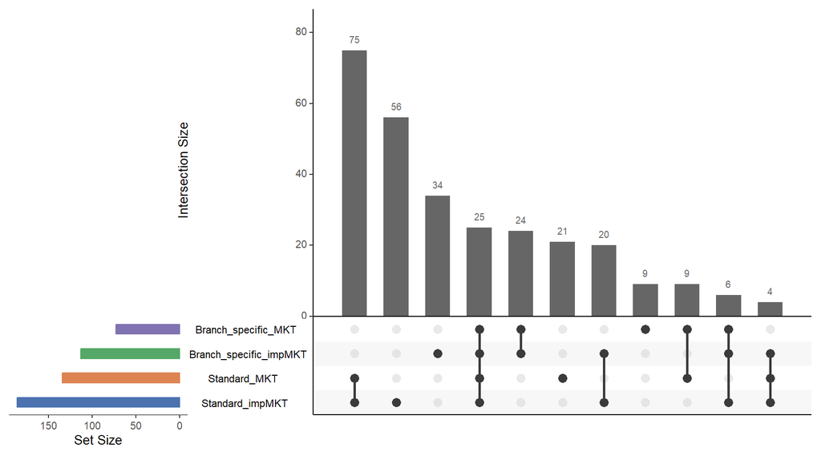

```r
UPSET_SETS <- c("Standard_MKT", "Standard_impMKT",
                "Branch_specific_MKT", "Branch_specific_impMKT")

upset_df <- bs_imp %>%
  filter(pos_any) %>%
  transmute(
    Standard_MKT           = as.integer(pos_standard_MKT),
    Standard_impMKT        = as.integer(pos_standard_impMKT),
    Branch_specific_MKT    = as.integer(pos_branch_specific_MKT),
    Branch_specific_impMKT = as.integer(pos_branch_specific_impMKT)
  ) %>%
  as.data.frame()

if (nrow(upset_df) > 0) {
  tryCatch(
    upset(
      upset_df,
      sets          = UPSET_SETS,
      nintersects   = 14,
      order.by      = "freq",
      sets.bar.color = c(CLR_STD, CLR_IMP, CLR_BS, CLR_BS_IMP),
      main.bar.color = "grey40",
      text.scale     = 1.2,
      point.size     = 3,
      line.size      = 1
    ),
    error = function(e) {
      message("UpSet plot unavailable: ", conditionMessage(e))
      barplot(
        colSums(upset_df),
        col   = c(CLR_STD, CLR_IMP, CLR_BS, CLR_BS_IMP),
        names.arg = c("Std", "Std imp", "BS", "BS imp"),
        ylab  = "Candidates",
        main  = "Positive candidates per test"
      )
    }
  )
} else {
  message("No positive selection candidates — UpSet plot skipped.")
}
```

### 8.2 MKT filter summary

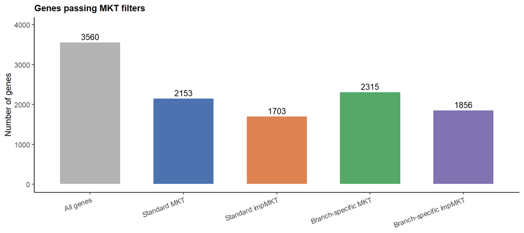

Number of genes at each analysis stage.

```r
filter_df <- tibble(
  Stage = factor(
    c("All genes", "Standard MKT", "Standard impMKT",
      "Branch-specific MKT", "Branch-specific impMKT"),
    levels = c("All genes", "Standard MKT", "Standard impMKT",
               "Branch-specific MKT", "Branch-specific impMKT")
  ),
  n = c(nrow(df), nrow(std_filtered), nrow(imp_filtered),
        nrow(bs_filtered), nrow(bs_imp_filtered))
)

ggplot(filter_df, aes(x = Stage, y = n, fill = Stage)) +
  geom_col(width = 0.65, colour = "white") +
  geom_text(aes(label = n), vjust = -0.4, size = 3.5) +
  scale_fill_manual(values = c(
    "All genes"               = "grey70",
    "Standard MKT"            = CLR_STD,
    "Standard impMKT"         = CLR_IMP,
    "Branch-specific MKT"     = CLR_BS,
    "Branch-specific impMKT"  = CLR_BS_IMP
  )) +
  labs(title = "Genes passing MKT filters", x = NULL, y = "Number of genes") +
  expand_limits(y = max(filter_df$n) * 1.12) +
  theme(legend.position = "none",
        axis.text.x = element_text(angle = 20, hjust = 1))
```

### 8.3 Alignment and polymorphism statistics

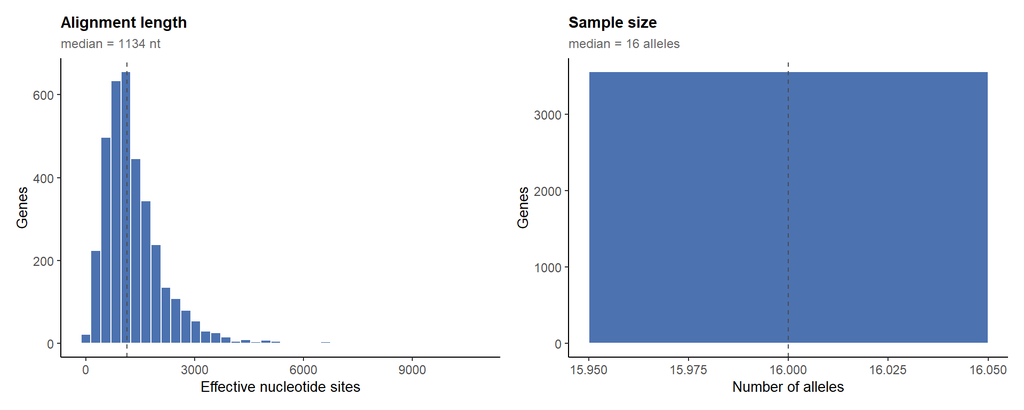

Effective nucleotide sites (left) and sample size (right). Dashed line = median.

```r
p_len <- ggplot(df, aes(x = number_sites)) +
  geom_histogram(bins = 40, fill = CLR_STD, colour = "white") +
  geom_vline(xintercept = median(df$number_sites, na.rm = TRUE),
             linetype = "dashed", colour = "grey30") +
  labs(title = "Alignment length",
       subtitle = sprintf("median = %d nt", round(median(df$number_sites, na.rm = TRUE))),
       x = "Effective nucleotide sites", y = "Genes")

p_ss <- ggplot(df, aes(x = sample_size)) +
  geom_histogram(bins = 30, fill = CLR_STD, colour = "white") +
  geom_vline(xintercept = median(df$sample_size, na.rm = TRUE),
             linetype = "dashed", colour = "grey30") +
  labs(title = "Sample size",
       subtitle = sprintf("median = %d alleles", round(median(df$sample_size, na.rm = TRUE))),
       x = "Number of alleles", y = "Genes")

p_len + p_ss
```

[figure not shown]

Population-genetics statistics. Top: nucleotide diversity and Watterson theta. Bottom: Tajima’s D and synonymous vs non-synonymous diversity.

```r
p_pi <- ggplot(df, aes(x = Pi_per_site)) +
  geom_histogram(bins = 40, fill = CLR_STD, colour = "white") +
  geom_vline(xintercept = median(df$Pi_per_site, na.rm = TRUE),
             linetype = "dashed", colour = "grey30") +
  labs(title = expression(paste("Nucleotide diversity ", pi, " per site")),
       x = "Pi_per_site", y = "Genes")

p_tw <- ggplot(df, aes(x = thetaW_per_site)) +
  geom_histogram(bins = 40, fill = CLR_STD, colour = "white") +
  labs(title = expression(paste("Watterson's ", theta, " per site")),
       x = "thetaW_per_site", y = "Genes")

p_td <- ggplot(df, aes(x = Tajimas_D)) +
  geom_histogram(bins = 40, fill = CLR_STD, colour = "white") +
  geom_vline(xintercept = 0, linetype = "dashed", colour = "grey30") +
  labs(title = "Tajima's D", x = "Tajimas_D", y = "Genes")

p_piSNS <- df %>%
  filter(!is.na(pi_S) & !is.na(pi_NS)) %>%
  ggplot(aes(x = pi_S, y = pi_NS)) +
  geom_point(alpha = 0.3, size = 1, colour = CLR_STD) +
  geom_abline(slope = 1, intercept = 0, linetype = "dashed", colour = "grey30") +
  labs(title = expression(paste(pi[NS], " vs ", pi[S])),
       subtitle = "Above diagonal: excess NS diversity",
       x = expression(pi[S]), y = expression(pi[NS]))

(p_pi + p_tw) / (p_td + p_piSNS)
```

### 8.4 Divergence count distributions

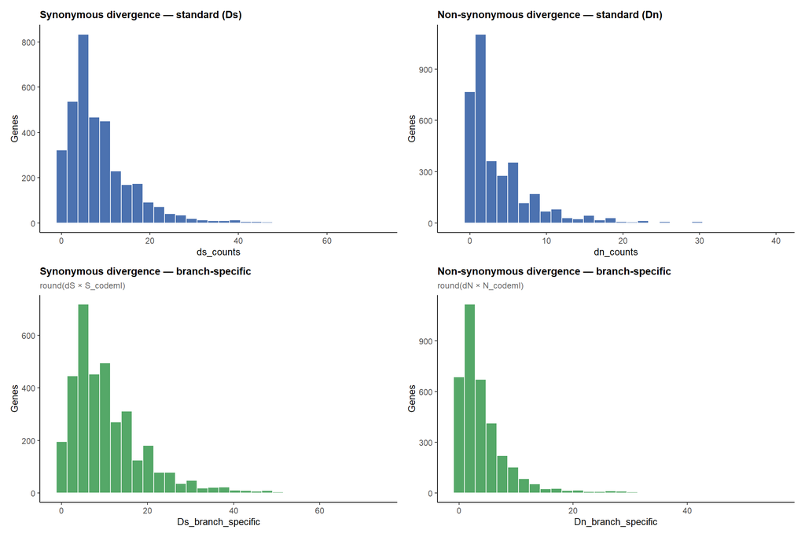

Standard Dn/Ds (fixN/fixS from dNdSpiNpiS; top row) and branch-specific Dn/Ds (codeml rates × sites; bottom row).

```r
p_Ds_std <- ggplot(df %>% filter(!is.na(ds_counts)), aes(x = ds_counts)) +
  geom_histogram(bins = 30, fill = CLR_STD, colour = "white") +
  labs(title = "Synonymous divergence — standard (Ds)", x = "ds_counts", y = "Genes")

p_Dn_std <- ggplot(df %>% filter(!is.na(dn_counts)), aes(x = dn_counts)) +
  geom_histogram(bins = 30, fill = CLR_STD, colour = "white") +
  labs(title = "Non-synonymous divergence — standard (Dn)", x = "dn_counts", y = "Genes")

p_Ds_bs <- ggplot(df %>% filter(!is.na(Ds_branch_specific)), aes(x = Ds_branch_specific)) +
  geom_histogram(bins = 30, fill = CLR_BS, colour = "white") +
  labs(title = "Synonymous divergence — branch-specific",
       subtitle = "round(dS × S_codeml)", x = "Ds_branch_specific", y = "Genes")

p_Dn_bs <- ggplot(df %>% filter(!is.na(Dn_branch_specific)), aes(x = Dn_branch_specific)) +
  geom_histogram(bins = 30, fill = CLR_BS, colour = "white") +
  labs(title = "Non-synonymous divergence — branch-specific",
       subtitle = "round(dN × N_codeml)", x = "Dn_branch_specific", y = "Genes")

(p_Ds_std + p_Dn_std) / (p_Ds_bs + p_Dn_bs)
```

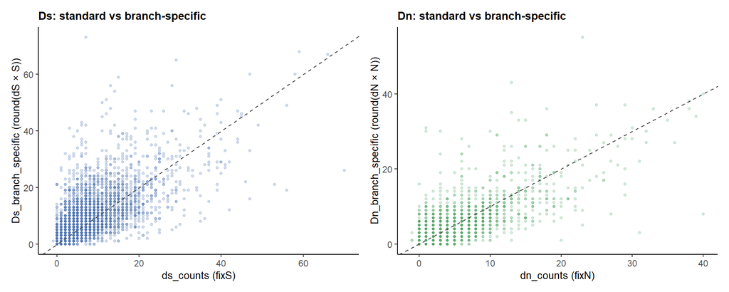

Correlation between standard and branch-specific divergence counts. Dashed line = 1:1.

```r
p_Ds_corr <- df %>%
  filter(!is.na(ds_counts) & !is.na(Ds_branch_specific)) %>%
  ggplot(aes(x = ds_counts, y = Ds_branch_specific)) +
  geom_point(alpha = 0.25, size = 1, colour = CLR_STD) +
  geom_abline(slope = 1, intercept = 0, linetype = "dashed", colour = "grey30") +
  labs(title = "Ds: standard vs branch-specific",
       x = "ds_counts (fixS)", y = "Ds_branch_specific (round(dS × S))")

p_Dn_corr <- df %>%
  filter(!is.na(dn_counts) & !is.na(Dn_branch_specific)) %>%
  ggplot(aes(x = dn_counts, y = Dn_branch_specific)) +
  geom_point(alpha = 0.25, size = 1, colour = CLR_BS) +
  geom_abline(slope = 1, intercept = 0, linetype = "dashed", colour = "grey30") +
  labs(title = "Dn: standard vs branch-specific",
       x = "dn_counts (fixN)", y = "Dn_branch_specific (round(dN × N))")

p_Ds_corr + p_Dn_corr
```

### 8.5 SDM estimation quality

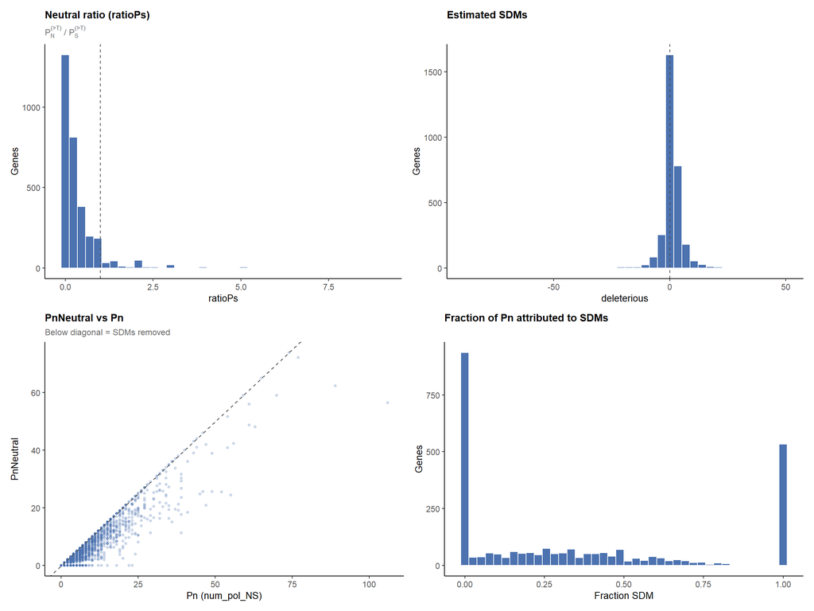

SDM diagnostics. Top: neutral ratio and estimated SDM count. Bottom: PnNeutral vs Pn, and fraction of Pn attributed to SDMs.

```r
p_ratio <- df %>%
  filter(!is.na(ratioPs) & is.finite(ratioPs)) %>%
  ggplot(aes(x = ratioPs)) +
  geom_histogram(bins = 40, fill = CLR_STD, colour = "white") +
  geom_vline(xintercept = 1, linetype = "dashed", colour = "grey30") +
  labs(title = "Neutral ratio (ratioPs)",
       subtitle = expression(paste("P"[N]^{"(>T)"}, " / P"[S]^{"(>T)"})),
       x = "ratioPs", y = "Genes")

p_del <- df %>%
  filter(!is.na(deleterious)) %>%
  ggplot(aes(x = deleterious)) +
  geom_histogram(bins = 40, fill = CLR_STD, colour = "white") +
  geom_vline(xintercept = 0, linetype = "dashed", colour = "grey30") +
  labs(title = "Estimated SDMs", x = "deleterious", y = "Genes")

p_pnneut <- bs_imp %>%
  filter(!is.na(num_pol_NS) & !is.na(PnNeutral_safe)) %>%
  ggplot(aes(x = num_pol_NS, y = PnNeutral_safe)) +
  geom_point(alpha = 0.25, size = 1, colour = CLR_STD) +
  geom_abline(slope = 1, intercept = 0, linetype = "dashed", colour = "grey30") +
  labs(title = "PnNeutral vs Pn", subtitle = "Below diagonal = SDMs removed",
       x = "Pn (num_pol_NS)", y = "PnNeutral")

p_frac <- bs_imp %>%
  filter(!is.na(num_pol_NS) & num_pol_NS > 0 & !is.na(deleterious)) %>%
  mutate(frac_del = pmax(0, deleterious) / num_pol_NS) %>%
  ggplot(aes(x = frac_del)) +
  geom_histogram(bins = 40, fill = CLR_STD, colour = "white") +
  labs(title = "Fraction of Pn attributed to SDMs", x = "Fraction SDM", y = "Genes")

(p_ratio + p_del) / (p_pnneut + p_frac)
```

### 8.6 Direction of Selection (DoS) distributions

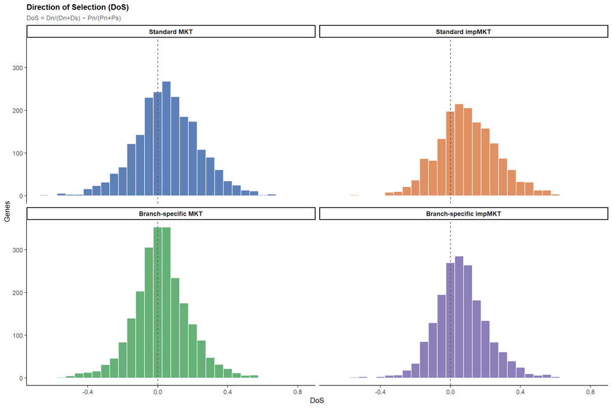

DoS = Dn/(Dn+Ds) − Pn/(Pn+Ps) for genes passing each filter. DoS > 0: positive selection; DoS < 0: purifying selection.

```r
bind_rows(
  std_filtered    %>% transmute(DoS = DoS_MKT_standard,           Test = "Standard MKT"),
  imp_filtered    %>% transmute(DoS = DoS_impMKT_standard,         Test = "Standard impMKT"),
  bs_filtered     %>% transmute(DoS = DoS_branch_specific_MKT,     Test = "Branch-specific MKT"),
  bs_imp_filtered %>% transmute(DoS = DoS_branch_specific_impMKT,  Test = "Branch-specific impMKT")
) %>%
  mutate(Test = factor(Test, levels = names(TEST_COLOURS))) %>%
  ggplot(aes(x = DoS, fill = Test)) +
  geom_histogram(binwidth = 0.05, colour = "white", alpha = 0.9) +
  geom_vline(xintercept = 0, linetype = "dashed", colour = "grey30") +
  facet_wrap(~Test, ncol = 2) +
  scale_fill_manual(values = TEST_COLOURS) +
  labs(title = "Direction of Selection (DoS)",
       subtitle = "DoS = Dn/(Dn+Ds) − Pn/(Pn+Ps)",
       x = "DoS", y = "Genes") +
  theme(legend.position = "none")
```

### 8.7 α (proportion of adaptive substitutions)

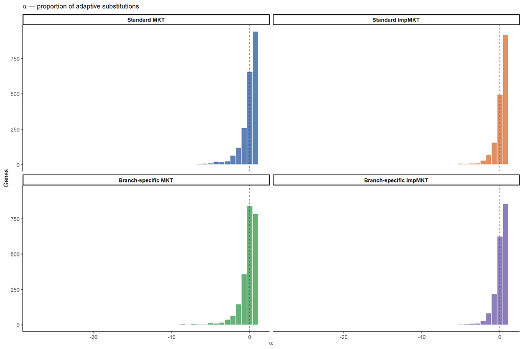

α = 1 − (Ds×Pn)/(Dn×Ps) for genes passing each filter.

```r
bind_rows(
  std_filtered    %>% transmute(alpha = standard_MKT,           Test = "Standard MKT"),
  imp_filtered    %>% transmute(alpha = standard_impMKT,         Test = "Standard impMKT"),
  bs_filtered     %>% transmute(alpha = branch_specific_MKT,     Test = "Branch-specific MKT"),
  bs_imp_filtered %>% transmute(alpha = branch_specific_impMKT,  Test = "Branch-specific impMKT")
) %>%
  mutate(Test = factor(Test, levels = names(TEST_COLOURS))) %>%
  filter(is.finite(alpha)) %>%
  ggplot(aes(x = alpha, fill = Test)) +
  geom_histogram(bins = 40, colour = "white", alpha = 0.9) +
  geom_vline(xintercept = 0, linetype = "dashed", colour = "grey30") +
  facet_wrap(~Test, ncol = 2) +
  scale_fill_manual(values = TEST_COLOURS) +
  labs(title = expression(paste(alpha, " — proportion of adaptive substitutions")),
       x = expression(alpha), y = "Genes") +
  theme(legend.position = "none")
```

### 8.8 p-value distributions

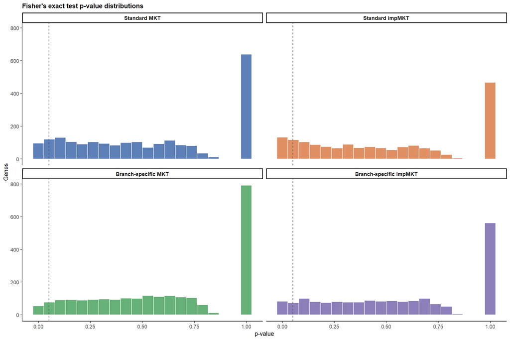

Fisher’s exact test p-value distributions. Enrichment near 0 indicates an excess of positive selection signals.

```r
bind_rows(
  std_filtered    %>% transmute(pval = standard_MKT_pvalue,           Test = "Standard MKT"),
  imp_filtered    %>% transmute(pval = standard_impMKT_pvalue,         Test = "Standard impMKT"),
  bs_filtered     %>% transmute(pval = branch_specific_MKT_pvalue,     Test = "Branch-specific MKT"),
  bs_imp_filtered %>% transmute(pval = branch_specific_impMKT_pvalue,  Test = "Branch-specific impMKT")
) %>%
  mutate(Test = factor(Test, levels = names(TEST_COLOURS))) %>%
  filter(!is.na(pval)) %>%
  ggplot(aes(x = pval, fill = Test)) +
  geom_histogram(bins = 20, colour = "white", alpha = 0.9) +
  geom_vline(xintercept = 0.05, linetype = "dashed", colour = "grey30") +
  facet_wrap(~Test, ncol = 2) +
  scale_fill_manual(values = TEST_COLOURS) +
  labs(title = "Fisher's exact test p-value distributions", x = "p-value", y = "Genes") +
  theme(legend.position = "none")
```

### 8.9 Volcano plots

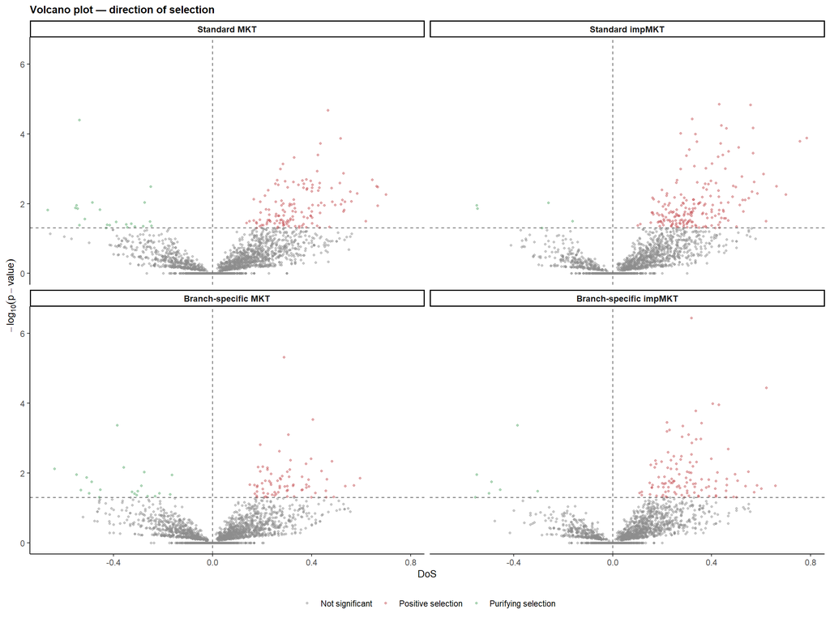

Volcano plots. Red: DoS > 0 and p < 0.05 (positive). Green: DoS < 0 and p < 0.05 (purifying). Grey: not significant.

```r
bind_rows(
  std_filtered    %>% transmute(DoS = DoS_MKT_standard,           pval = standard_MKT_pvalue,        Test = "Standard MKT"),
  imp_filtered    %>% transmute(DoS = DoS_impMKT_standard,         pval = standard_impMKT_pvalue,      Test = "Standard impMKT"),
  bs_filtered     %>% transmute(DoS = DoS_branch_specific_MKT,     pval = branch_specific_MKT_pvalue,  Test = "Branch-specific MKT"),
  bs_imp_filtered %>% transmute(DoS = DoS_branch_specific_impMKT,  pval = branch_specific_impMKT_pvalue, Test = "Branch-specific impMKT")
) %>%
  filter(!is.na(DoS) & !is.na(pval)) %>%
  mutate(
    log10p   = -log10(pval),
    Test     = factor(Test, levels = names(TEST_COLOURS)),
    category = case_when(
      DoS > 0 & pval < 0.05 ~ "Positive selection",
      DoS < 0 & pval < 0.05 ~ "Purifying selection",
      TRUE                  ~ "Not significant"
    )
  ) %>%
  ggplot(aes(x = DoS, y = log10p, colour = category)) +
  geom_point(alpha = 0.45, size = 0.9) +
  geom_hline(yintercept = -log10(0.05), linetype = "dashed", colour = "grey40") +
  geom_vline(xintercept = 0,            linetype = "dashed", colour = "grey40") +
  facet_wrap(~Test, ncol = 2) +
  scale_colour_manual(values = c(
    "Positive selection"  = CLR_POS,
    "Purifying selection" = CLR_NEG,
    "Not significant"     = CLR_NTRL
  )) +
  labs(title = "Volcano plot — direction of selection",
       x = "DoS", y = expression(-log[10](p-value)), colour = NULL) +
  theme(legend.position = "bottom")
```

### 8.10 Classic McDonald-Kreitman plots

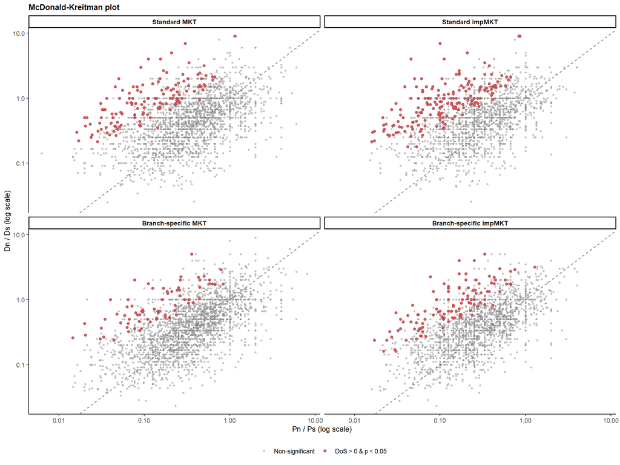

McDonald-Kreitman plots. Points above 1:1 diagonal: higher Dn/Ds than Pn/Ps. Red = DoS > 0 and p < 0.05.

```r
bind_rows(
  std_filtered %>% filter(Ps > 0 & Ds > 0) %>%
    transmute(pnps = Pn/Ps, dnds = Dn/Ds,
              sel = DoS_MKT_standard > 0 & standard_MKT_pvalue < 0.05,
              Test = "Standard MKT"),
  imp_filtered %>% filter(Ps > 0 & Ds > 0) %>%
    transmute(pnps = PnNeutral_safe/Ps, dnds = Dn/Ds,
              sel = DoS_impMKT_standard > 0 & standard_impMKT_pvalue < 0.05,
              Test = "Standard impMKT"),
  bs_filtered %>% filter(Ps > 0 & Ds_bs > 0) %>%
    transmute(pnps = Pn/Ps, dnds = Dn_bs/Ds_bs,
              sel = DoS_branch_specific_MKT > 0 & branch_specific_MKT_pvalue < 0.05,
              Test = "Branch-specific MKT"),
  bs_imp_filtered %>% filter(Ps > 0 & Ds_bs > 0) %>%
    transmute(pnps = PnNeutral_safe/Ps, dnds = Dn_bs/Ds_bs,
              sel = DoS_branch_specific_impMKT > 0 & branch_specific_impMKT_pvalue < 0.05,
              Test = "Branch-specific impMKT")
) %>%
  filter(is.finite(pnps) & is.finite(dnds)) %>%
  mutate(Test = factor(Test, levels = names(TEST_COLOURS))) %>%
  # Draw non-significant (grey) points first and significant (red) points last/on
  # top within each facet, so candidates are never hidden under the grey cloud.
  arrange(sel) %>%
  ggplot(aes(x = pnps, y = dnds, colour = sel)) +
  geom_point(data = ~ filter(.x, !sel), alpha = 0.5,  size = 0.9) +
  geom_point(data = ~ filter(.x,  sel), alpha = 0.9,  size = 1.6) +
  geom_abline(slope = 1, intercept = 0, linetype = "dashed", colour = "grey40") +
  scale_colour_manual(
    values = c("TRUE" = CLR_POS, "FALSE" = CLR_NTRL),
    labels = c("TRUE" = "DoS > 0 & p < 0.05", "FALSE" = "Non-significant"),
    name   = NULL
  ) +
  scale_x_log10() + scale_y_log10() +
  facet_wrap(~Test, ncol = 2) +
  labs(title = "McDonald-Kreitman plot",
       x = "Pn / Ps (log scale)", y = "Dn / Ds (log scale)") +
  theme(legend.position = "bottom")
```

### 8.11 DoS comparison: standard vs branch-specific

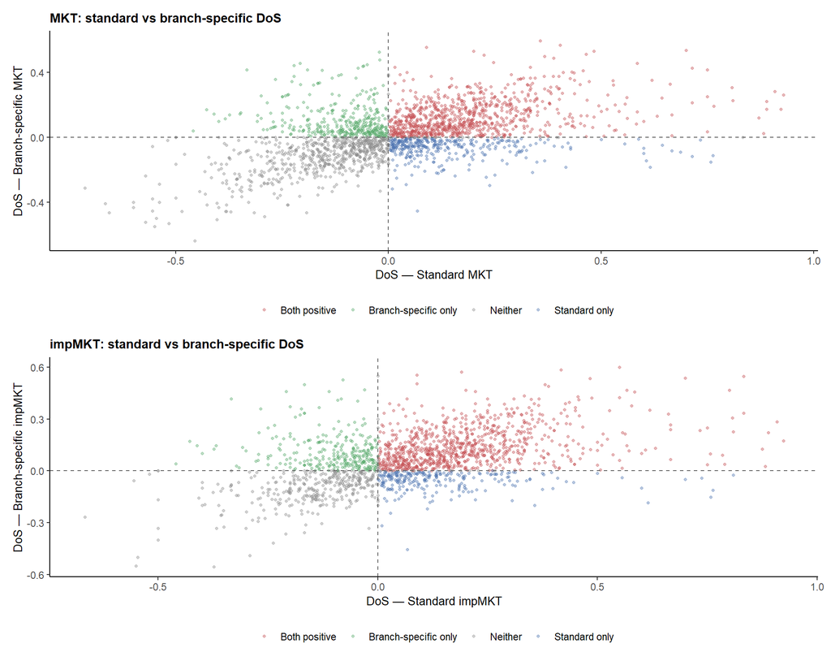

Cross-test DoS comparison. Red: positive in both, blue: positive only in standard, green: positive only in branch-specific, grey: neither.

```r
make_compare <- function(data, dos_x, dos_y, label_x, label_y, title) {
  data %>%
    select(gene_id, x = {{ dos_x }}, y = {{ dos_y }}) %>%
    filter(!is.na(x) & !is.na(y)) %>%
    mutate(category = case_when(
      x > 0 & y > 0 ~ "Both positive",
      x > 0 & y < 0 ~ "Standard only",
      x < 0 & y > 0 ~ "Branch-specific only",
      TRUE           ~ "Neither"
    )) %>%
    ggplot(aes(x = x, y = y, colour = category)) +
    geom_point(alpha = 0.4, size = 0.9) +
    geom_hline(yintercept = 0, linetype = "dashed", colour = "grey40") +
    geom_vline(xintercept = 0, linetype = "dashed", colour = "grey40") +
    scale_colour_manual(values = c(
      "Both positive"        = CLR_POS,
      "Standard only"        = CLR_STD,
      "Branch-specific only" = CLR_BS,
      "Neither"              = CLR_NTRL
    )) +
    labs(title = title, x = label_x, y = label_y, colour = NULL) +
    theme(legend.position = "bottom")
}

p_cmp1 <- make_compare(bs_filtered, DoS_MKT_standard, DoS_branch_specific_MKT,
  "DoS — Standard MKT", "DoS — Branch-specific MKT",
  "MKT: standard vs branch-specific DoS")

p_cmp2 <- make_compare(bs_imp_filtered, DoS_impMKT_standard, DoS_branch_specific_impMKT,
  "DoS — Standard impMKT", "DoS — Branch-specific impMKT",
  "impMKT: standard vs branch-specific DoS")

p_cmp1 / p_cmp2
```

### 8.12 omega (codeml) vs DoS from branch-specific tests

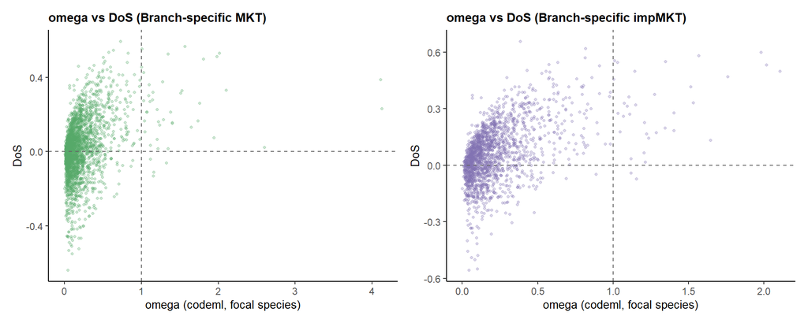

Branch-specific omega (codeml, focal species) versus DoS from branch-specific MKT (left) and impMKT (right).

```r
p_om1 <- bs_filtered %>%
  filter(!is.na(omega) & !is.na(DoS_branch_specific_MKT)) %>%
  ggplot(aes(x = omega, y = DoS_branch_specific_MKT)) +
  geom_point(alpha = 0.3, size = 0.9, colour = CLR_BS) +
  geom_hline(yintercept = 0, linetype = "dashed", colour = "grey40") +
  geom_vline(xintercept = 1, linetype = "dashed", colour = "grey40") +
  labs(title = "omega vs DoS (Branch-specific MKT)",
       x = "omega (codeml, focal species)", y = "DoS")

p_om2 <- bs_imp_filtered %>%
  filter(!is.na(omega) & !is.na(DoS_branch_specific_impMKT)) %>%
  ggplot(aes(x = omega, y = DoS_branch_specific_impMKT)) +
  geom_point(alpha = 0.3, size = 0.9, colour = CLR_BS_IMP) +
  geom_hline(yintercept = 0, linetype = "dashed", colour = "grey40") +
  geom_vline(xintercept = 1, linetype = "dashed", colour = "grey40") +
  labs(title = "omega vs DoS (Branch-specific impMKT)",
       x = "omega (codeml, focal species)", y = "DoS")

p_om1 + p_om2
```

### 8.13 Dn/Ds vs Pn/Ps by species (candidates highlighted)

Reproduces the `plot_pnps_dnds_by_species.R` figure inline: one Dn/Ds-vs-Pn/Ps panel per species (this focal species plus any others supplied via `params$other_results`), stacked by MKT test. A gene is drawn in red only if it is a genuine candidate for *that* test — i.e. it both clears that test’s own `mk_filter()` and has DoS > 0 with raw p < 0.05 — matching the same gating used everywhere else in this report (§4.5, §7).

```r
# Columns needed from each species' result table to recompute Pn/Ps/Dn/Ds and
# significance for all four tests. Recomputing from raw counts (rather than
# trusting a possibly-older file's own pos_* columns) keeps this consistent
# even if an "other" species file predates a mk_filter/gating fix.
pnps_dnds_cols <- c(
  "num_pol_NS", "num_pol_S", "dn_counts", "ds_counts",
  "PnNeutral", "Dn_branch_specific", "Ds_branch_specific",
  "DoS_MKT_standard", "standard_MKT_pvalue",
  "DoS_impMKT_standard", "standard_impMKT_pvalue",
  "DoS_branch_specific_MKT", "branch_specific_MKT_pvalue",
  "DoS_branch_specific_impMKT", "branch_specific_impMKT_pvalue"
)

current_sp_df <- bs_imp %>%
  transmute(
    num_pol_NS = Pn, num_pol_S = Ps,
    dn_counts  = Dn, ds_counts = Ds,
    PnNeutral  = PnNeutral_safe,
    Dn_branch_specific = Dn_bs, Ds_branch_specific = Ds_bs,
    DoS_MKT_standard, standard_MKT_pvalue,
    DoS_impMKT_standard, standard_impMKT_pvalue,
    DoS_branch_specific_MKT, branch_specific_MKT_pvalue,
    DoS_branch_specific_impMKT, branch_specific_impMKT_pvalue
  ) %>%
  mutate(species = params$species)

other_sp_dfs <- if (length(params$other_results) > 0) {
  imap(params$other_results, function(path, sp_name) {
    if (!file.exists(path)) {
      warning("Other species file not found, skipping: ", path)
      return(NULL)
    }
    read_tsv(path, show_col_types = FALSE, na = c("NA", "NaN", "")) %>%
      select(any_of(pnps_dnds_cols)) %>%
      mutate(species = sp_name)
  }) %>% compact()
} else {
  list()
}

pnps_dnds_all <- bind_rows(current_sp_df, other_sp_dfs)
```

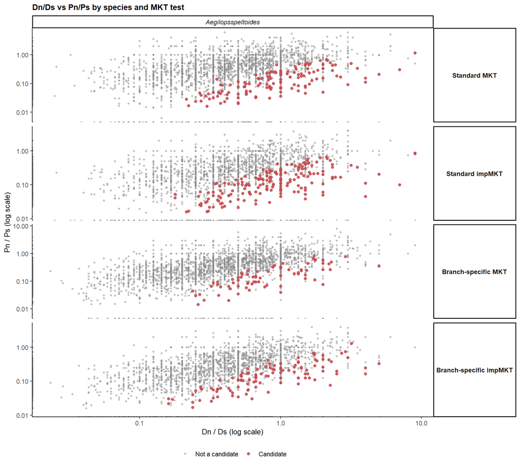

Dn/Ds vs Pn/Ps by species (columns) and MKT test (rows). Red: candidate (passes that test’s mk_filter and DoS>0, p<0.05).

```r
pnps_dnds_tests <- list(
  "Standard MKT"           = list(Pn = "num_pol_NS", Ps = "num_pol_S",
                                   Dn = "dn_counts",  Ds = "ds_counts",
                                   dos = "DoS_MKT_standard", pval = "standard_MKT_pvalue"),
  "Standard impMKT"        = list(Pn = "PnNeutral",  Ps = "num_pol_S",
                                   Dn = "dn_counts",  Ds = "ds_counts",
                                   dos = "DoS_impMKT_standard", pval = "standard_impMKT_pvalue"),
  "Branch-specific MKT"    = list(Pn = "num_pol_NS", Ps = "num_pol_S",
                                   Dn = "Dn_branch_specific", Ds = "Ds_branch_specific",
                                   dos = "DoS_branch_specific_MKT", pval = "branch_specific_MKT_pvalue"),
  "Branch-specific impMKT" = list(Pn = "PnNeutral",  Ps = "num_pol_S",
                                   Dn = "Dn_branch_specific", Ds = "Ds_branch_specific",
                                   dos = "DoS_branch_specific_impMKT", pval = "branch_specific_impMKT_pvalue")
)

pnps_dnds_long <- imap_dfr(pnps_dnds_tests, function(cfg, test_label) {
  pnps_dnds_all %>%
    transmute(
      species = species,
      Pn = .data[[cfg$Pn]], Ps = .data[[cfg$Ps]],
      Dn = .data[[cfg$Dn]], Ds = .data[[cfg$Ds]],
      dos = .data[[cfg$dos]], pval = .data[[cfg$pval]]
    ) %>%
    mutate(
      pnps      = Pn / Ps,
      dnds      = Dn / Ds,
      candidate = mk_filter(Pn, Ps, Dn, Ds) & is_positive(dos, pval),
      Test      = factor(test_label, levels = names(pnps_dnds_tests))
    ) %>%
    filter(is.finite(pnps) & is.finite(dnds))
}) %>%
  arrange(candidate)   # draw candidates (red) last/on top within each panel

ggplot(pnps_dnds_long, aes(x = dnds, y = pnps, colour = candidate)) +
  geom_point(data = ~ filter(.x, !candidate), alpha = 0.5, size = 0.9) +
  geom_point(data = ~ filter(.x,  candidate), alpha = 0.9, size = 1.6) +
  scale_colour_manual(
    values = c("TRUE" = CLR_POS, "FALSE" = CLR_NTRL),
    labels = c("TRUE" = "Candidate", "FALSE" = "Not a candidate"),
    name   = NULL
  ) +
  scale_x_log10() + scale_y_log10() +
  facet_grid(Test ~ species, scales = "free") +
  labs(title = "Dn/Ds vs Pn/Ps by species and MKT test",
       x = "Dn / Ds (log scale)", y = "Pn / Ps (log scale)") +
  theme(legend.position = "bottom",
        strip.text.y = element_text(angle = 0, face = "bold"),
        strip.text.x = element_text(face = "italic"))
```